# TD1

## Exercice 1

1. Create a vector of number
   - The list from 1 to 100

   ```r
   seq(1,100)
   ```

   ```
   ##   [1]   1   2   3   4   5   6   7   8   9  10  11  12  13  14  15  16  17
   ##  [18]  18  19  20  21  22  23  24  25  26  27  28  29  30  31  32  33  34
   ##  [35]  35  36  37  38  39  40  41  42  43  44  45  46  47  48  49  50  51
   ##  [52]  52  53  54  55  56  57  58  59  60  61  62  63  64  65  66  67  68
   ##  [69]  69  70  71  72  73  74  75  76  77  78  79  80  81  82  83  84  85
   ##  [86]  86  87  88  89  90  91  92  93  94  95  96  97  98  99 100
   ```

   - A number list/sequence for 10, 20, 25, 50, repeated 5 times ( 10 20 25 50 10 20 25 50 10 20 25 50 10 20 25 50 10 20 25 50)

   ```r
   rep(c(10,20,25,50),5)
   ```

   ```
   ##  [1] 10 20 25 50 10 20 25 50 10 20 25 50 10 20 25 50 10 20 25 50
   ```

   - a list from 1 to 100, with a step of 5

   ```r
   seq(1,100,5)
   ```

   ```
   ##  [1]  1  6 11 16 21 26 31 36 41 46 51 56 61 66 71 76 81 86 91 96
   ```

   - Repeat 10 times the number 12

   ```r
   rep(12,10)
   ```

   ```
   ##  [1] 12 12 12 12 12 12 12 12 12 12
   ```

2. A vector with the number 1, 2, 3 with a repetition of each 4 times with in addition a repetition of the sequence of 4 times
   - Put this vector in the object « VEC »

   ```r
   VEC = rep(c(1,2,3),each = 4, times = 4)
   VEC
   ```

   ```
   ##  [1] 1 1 1 1 2 2 2 2 3 3 3 3 1 1 1 1 2 2 2 2 3 3 3 3 1 1 1 1 2 2 2 2 3 3 3
   ## [36] 3 1 1 1 1 2 2 2 2 3 3 3 3
   ```

   - Multiply all the element of VEC by 5

   ```r
   VEC = VEC * 5
   VEC
   ```

   ```
   ##  [1]  5  5  5  5 10 10 10 10 15 15 15 15  5  5  5  5 10 10 10 10 15 15 15
   ## [24] 15  5  5  5  5 10 10 10 10 15 15 15 15  5  5  5  5 10 10 10 10 15 15
   ## [47] 15 15
   ```

   - Calculate the median and the quantile of 75%

   ```r
   quantile(VEC, 0.5) # Median
   ```

   ```
   ## 50%
   ##  10
   ```

   ```r
   quantile(VEC, 0.75)
   ```

   ```
   ## 75%
   ##  15
   ```

3. Create a vector with a serie of number from 1 to 2000 with a step of 10
   - Put it in the object « vec »

   ```r
   vec = seq(1,2000,10)
   vec
   ```

   ```
   ##   [1]    1   11   21   31   41   51   61   71   81   91  101  111  121  131
   ##  [15]  141  151  161  171  181  191  201  211  221  231  241  251  261  271
   ##  [29]  281  291  301  311  321  331  341  351  361  371  381  391  401  411
   ##  [43]  421  431  441  451  461  471  481  491  501  511  521  531  541  551
   ##  [57]  561  571  581  591  601  611  621  631  641  651  661  671  681  691
   ##  [71]  701  711  721  731  741  751  761  771  781  791  801  811  821  831
   ##  [85]  841  851  861  871  881  891  901  911  921  931  941  951  961  971
   ##  [99]  981  991 1001 1011 1021 1031 1041 1051 1061 1071 1081 1091 1101 1111
   ## [113] 1121 1131 1141 1151 1161 1171 1181 1191 1201 1211 1221 1231 1241 1251
   ## [127] 1261 1271 1281 1291 1301 1311 1321 1331 1341 1351 1361 1371 1381 1391
   ## [141] 1401 1411 1421 1431 1441 1451 1461 1471 1481 1491 1501 1511 1521 1531
   ## [155] 1541 1551 1561 1571 1581 1591 1601 1611 1621 1631 1641 1651 1661 1671
   ## [169] 1681 1691 1701 1711 1721 1731 1741 1751 1761 1771 1781 1791 1801 1811
   ## [183] 1821 1831 1841 1851 1861 1871 1881 1891 1901 1911 1921 1931 1941 1951
   ## [197] 1961 1971 1981 1991
   ```

   - Extract the 10 th value of vec

   ```r
   vec[10]
   ```

   ```
   ## [1] 91
   ```

   - Display a sub-vector called « vec2 » that corresponds to the values from 2 to 6

   ```r
   vec2 = vec[2:6]
   vec2
   ```

   ```
   ## [1] 11 21 31 41 51
   ```

   - Replace the last value of vec2 by 100

   ```r
   vec2[length(vec2)] = 100
   vec2
   ```

   ```
   ## [1]  11  21  31  41 100
   ```

   - Display vec2 without its 3th value and store it in vec3

   ```r
   vec3 = vec2[-3]
   vec3
   ```

   ```
   ## [1]  11  21  41 100
   ```

   - Replace all the values >= 30 by 30

   ```r
   vec3[vec3 >= 30] = 30
   vec3
   ```

   ```
   ## [1] 11 21 30 30
   ```

## Exercice 2 : Opérations avec les tables

Create a matric with 5 columns and 20 lines with the values from 1 to 100, by lines - Call it MAT

```r
MAT = matrix(1:100,byrow = TRUE, ncol = 5)
MAT
```

```
##       [,1] [,2] [,3] [,4] [,5]
##  [1,]    1    2    3    4    5
##  [2,]    6    7    8    9   10
##  [3,]   11   12   13   14   15
##  [4,]   16   17   18   19   20
##  [5,]   21   22   23   24   25
##  [6,]   26   27   28   29   30
##  [7,]   31   32   33   34   35
##  [8,]   36   37   38   39   40
##  [9,]   41   42   43   44   45
## [10,]   46   47   48   49   50
## [11,]   51   52   53   54   55
## [12,]   56   57   58   59   60
## [13,]   61   62   63   64   65
## [14,]   66   67   68   69   70
## [15,]   71   72   73   74   75
## [16,]   76   77   78   79   80
## [17,]   81   82   83   84   85
## [18,]   86   87   88   89   90
## [19,]   91   92   93   94   95
## [20,]   96   97   98   99  100
```

- Display the value at the second line and 5 th column et replace it by NA

```r
MAT[2,5] = NA
MAT
```

```
##       [,1] [,2] [,3] [,4] [,5]
##  [1,]    1    2    3    4    5
##  [2,]    6    7    8    9   NA
##  [3,]   11   12   13   14   15
##  [4,]   16   17   18   19   20
##  [5,]   21   22   23   24   25
##  [6,]   26   27   28   29   30
##  [7,]   31   32   33   34   35
##  [8,]   36   37   38   39   40
##  [9,]   41   42   43   44   45
## [10,]   46   47   48   49   50
## [11,]   51   52   53   54   55
## [12,]   56   57   58   59   60
## [13,]   61   62   63   64   65
## [14,]   66   67   68   69   70
## [15,]   71   72   73   74   75
## [16,]   76   77   78   79   80
## [17,]   81   82   83   84   85
## [18,]   86   87   88   89   90
## [19,]   91   92   93   94   95
## [20,]   96   97   98   99  100
```

- Create “mat “ with only the columns 2,3 and 4 (taking them from MAT)

```r
mat = MAT[,2:4]
mat
```

```
##       [,1] [,2] [,3]
##  [1,]    2    3    4
##  [2,]    7    8    9
##  [3,]   12   13   14
##  [4,]   17   18   19
##  [5,]   22   23   24
##  [6,]   27   28   29
##  [7,]   32   33   34
##  [8,]   37   38   39
##  [9,]   42   43   44
## [10,]   47   48   49
## [11,]   52   53   54
## [12,]   57   58   59
## [13,]   62   63   64
## [14,]   67   68   69
## [15,]   72   73   74
## [16,]   77   78   79
## [17,]   82   83   84
## [18,]   87   88   89
## [19,]   92   93   94
## [20,]   97   98   99
```

```r
mat[mat>40 && mat<60] = 50
mat
```

```
##       [,1] [,2] [,3]
##  [1,]    2    3    4
##  [2,]    7    8    9
##  [3,]   12   13   14
##  [4,]   17   18   19
##  [5,]   22   23   24
##  [6,]   27   28   29
##  [7,]   32   33   34
##  [8,]   37   38   39
##  [9,]   42   43   44
## [10,]   47   48   49
## [11,]   52   53   54
## [12,]   57   58   59
## [13,]   62   63   64
## [14,]   67   68   69
## [15,]   72   73   74
## [16,]   77   78   79
## [17,]   82   83   84
## [18,]   87   88   89
## [19,]   92   93   94
## [20,]   97   98   99
```

## Exercise 3. Operations with a table of decimal numbers

1. Get the file (moodle) M&Ms.xls and open it with excel or open-office
- save it as MetMs.txt
- Import it in R and store it in data

```r
library(readxl)
data <- read_excel("~/Téléchargements/MetMs.xlsx")
```

```r
data2 = subset(data, select = -Forme)
data2 = na.omit(data2)
data2
```

```
## # A tibble: 100 x 4
##    Indice Couleur `Longueur maximale (mm)` `Poids (g)`
##     <dbl> <chr>                      <dbl>       <dbl>
##  1      1 Orange                      17.4         2
##  2      2 Bleu                        20.9         2.4
##  3      3 Vert                        15.1         1.9
##  4      4 Jaune                       15.4         2
##  5      5 Bleu                        15.6         1.7
##  6      6 Marron                      17.6         2.9
##  7      7 Marron                      14.2         1.7
##  8      8 Bleu                        15.7         2.3
##  9      9 Marron                      17.3         2.4
## 10     10 Jaune                       16.9         2.5
## # ... with 90 more rows
```

- Determine for which colors the lengths are minimal and maximal

```r
with(data2, Couleur[`Longueur maximale (mm)` == min(`Longueur maximale (mm)`)])
```

```
## [1] "Bleu"
```

```r
with(data2, Couleur[`Longueur maximale (mm)` == max(`Longueur maximale (mm)`)])
```

```
## [1] "Rouge"
```

- Sort the lines of data2 according to an increasing order of the length

```r
data2[order(data2$`Longueur maximale (mm)`),]
```

```
## # A tibble: 100 x 4
##    Indice Couleur `Longueur maximale (mm)` `Poids (g)`
##     <dbl> <chr>                      <dbl>       <dbl>
##  1     13 Bleu                        12.8         1.2
##  2     99 Bleu                        13.4         1.2
##  3     60 Vert                        13.7         1.7
##  4     67 Jaune                       14           1.5
##  5      7 Marron                      14.2         1.7
##  6     87 Vert                        14.5         1.6
##  7     93 Orange                      14.5         1.8
##  8     11 Rouge                       14.6         1.9
##  9     97 Bleu                        14.9         1.7
## 10     92 Orange                      15           1.9
## # ... with 90 more rows
```

## Exercice 4. Graphics

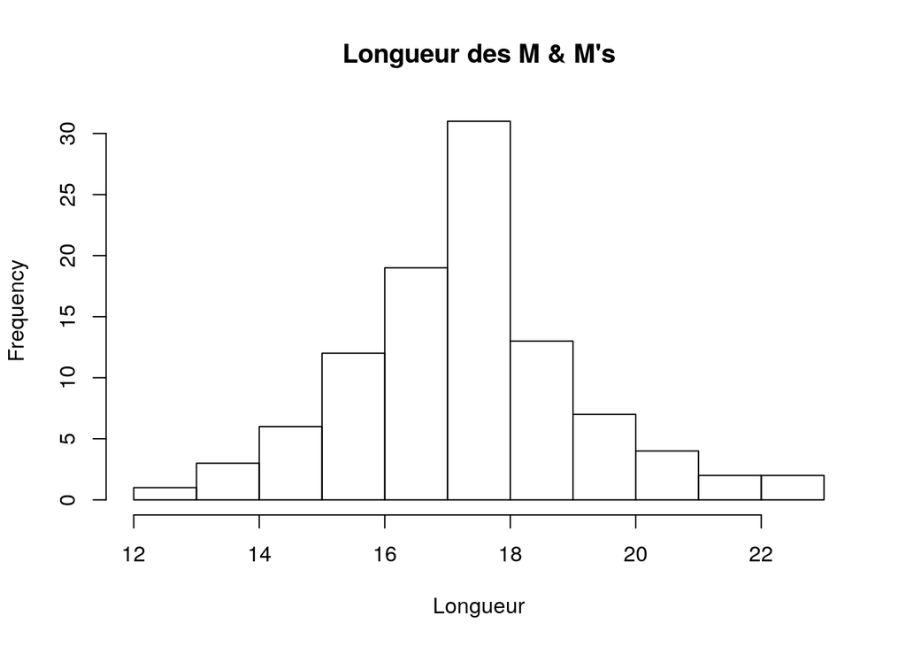

```r
hist(data2$`Longueur maximale (mm)`, xlab = "Longueur", main = "Longueur des M & M's")
```

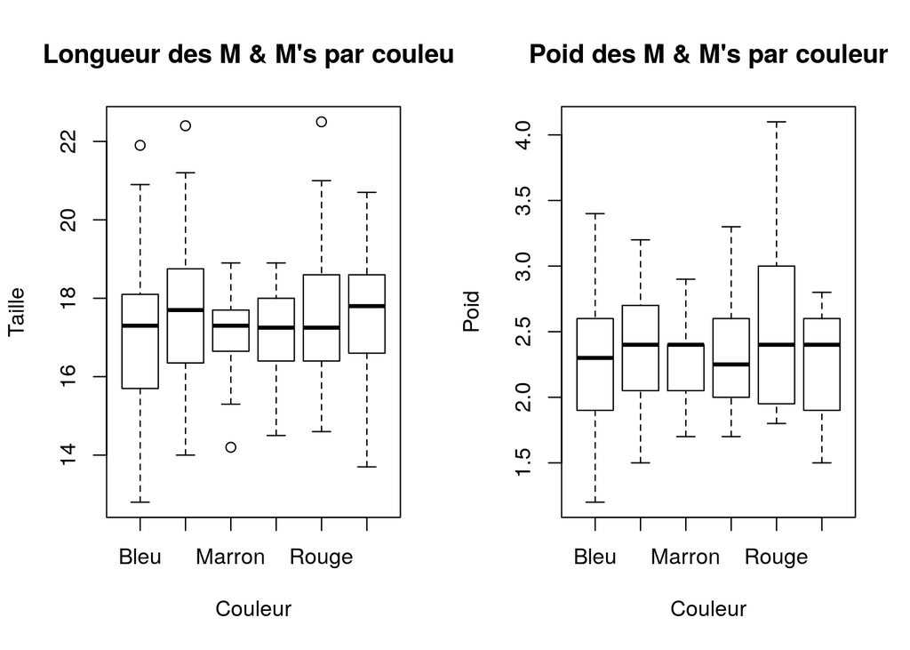

```r
par(mfrow=c(1,2))
boxplot(data = data2,`Longueur maximale (mm)`~ Couleur , main = "Longueur des M & M's par couleur", xlab= "Couleur", ylab= "Taille")
boxplot(data = data2,`Poids (g)`~ Couleur , main = "Poid des M & M's par couleur", xlab= "Couleur", ylab= "Poid")
```